# Ökonometrie Aufgabe - Datensatz 2

## Deskriptive Bescheibung des Datensatzes

### Basis

Der Datensatz umfasst 1462 Beobachtungen im Zeitraum vom 1.1.2013. bis 1.1.2017. Es handelt sich um täglichen Wetterdaten das heißt, dass die Beobachtungseinheit ist ein einzelner Kalendartag

Die Daten sind bereinigt und überprüft wurde:

- das Datum ist in korektes Format,
- die daten sind chonologisch soritiert,
- doppelte Datumsangabe ist entfernt,
- und letztes geprüft wurde ob fehlende Kalendartage existieren.

Die gesamte Überprüfung zeigt, dass keine Felhende Tage, Duplikate im Datum und keine Fehlende Werte (NA) in Variablen gibt.

Damit ist der Datensatz vollstandig und konsistent strukturiert.

### Merkmalsbeschreibung

| Merkmale | Bedeutung | Skalenniveau | Einheit |
| --- | --- | --- | --- |
| meantemp | Durchschnitstemperatur | metrisch | °C |
| humidity | Luftfeuchtigkeit | metrisch | % |
| wind_speed | Windgeschwindigkeit | metrisch | km/h |
| meanpressure | Luftdruck | metrisch | hPa |

Alle Variable sind metrisch skaliert und stetig

### Lage- und Steuerungmaße

Die Durchschnittstemperatur beträgt im Mittel 25,50 °C. Die Werte befident sich zwischen 6.00 °C und 38.71°C, zeigt deutliche saisonale Schwankugen.

Die Luftfeuchtikeit weist einen Mittelwert von 60.77% und varriert zwischen 13.43% und 100%. Das ist eine hohe Spannweite und weist auf unteschielische klimatische Bedigungen im Jahresverlauf hin.

Besonders affällig ist der Luftdruck, weil der Median bei 1008,56 hPa liegt und das erste sowie dritte Quartil in einem möglichen Bereich liegen, treten Extremwerte von -3,04 hPa sowie 7679 hPa auf. Prüfen auf Plausibilität

```r
df %>% summarise(
  min_temp = min(meantemp, na.rm = TRUE),
  sd_temp = sd(meantemp, na.rm = TRUE),
  var_temp = var(meantemp, na.rm = TRUE),
  max_temp = max(meantemp, na.rm = TRUE),
  min_hum  = min(humidity, na.rm = TRUE),
  sd_hum = sd(humidity, na.rm = TRUE),
  var_hum = var(humidity, na.rm = TRUE),
  max_hum  = max(humidity, na.rm = TRUE),
  min_wind = min(wind_speed, na.rm = TRUE),
  sd_wind = sd(wind_speed, na.rm = TRUE),
  var_wind = var(wind_speed, na.rm = TRUE),
  max_wind = max(wind_speed, na.rm = TRUE),
  min_pres = min(meanpressure, na.rm = TRUE),
  sd_pres = sd(meanpressure, na.rm = TRUE),
  var_pres = var(meanpressure, na.rm = TRUE),
  max_pres = max(meanpressure, na.rm = TRUE)
)
```

| min_temp | sd_temp | var_temp | max_temp | min_hum | sd_hum | var_hum | max_hum | min_wind | sd_wind | var_wind | max_wind | min_pres | sd_pres | var_pres | max_pres |
| --- | --- | --- | --- | --- | --- | --- | --- | --- | --- | --- | --- | --- | --- | --- | --- |
| 6 | 7.348103 | 53.99461 | 38.71429 | 13.42857 | 16.76965 | 281.2212 | 100 | 0 | 4.561602 | 20.80821 | 42.22 | -3.041667 | 180.2317 | 32483.45 | 7679.333 |

```r
# Messfehler/Falsche Daten/etc
df %>% filter(humidity < 0 | humidity > 100)
```

| date | meantemp | humidity | wind_speed | meanpressure |
| --- | --- | --- | --- | --- |

```r
df %>% filter(wind_speed < 0)
```

| date | meantemp | humidity | wind_speed | meanpressure |
| --- | --- | --- | --- | --- |

```r
#df %>% filter(meanpressure > 900 & meanpressure < 1100)
df <- df %>%
  filter(meanpressure > 900 & meanpressure < 1100)
```

Zur genaueren Beurteilung der Variabilität wurden Standardabweichung und Varianz berechnet.

### Temperatur (meantemp)

Die Temperatur weist eine moderate Streuung auf.  
Die Standardabweichung von 7,35 °C zeigt deutliche Schwankungen um den Mittelwert, was mit der visuell erkennbaren saisonalen Struktur konsistent ist.  
Die Varianz bleibt jedoch in einem realistischen Bereich und deutet nicht auf extreme Instabilität hin.

### Luftdruck (meanpressure)

Die extrem hohe Varianz des Luftdrucks ist auffällig.  
Sie wird offensichtlich durch einzelne extreme Ausreißer verursacht.  
Da typische atmosphärische Druckwerte im Bereich von etwa 950–1050 hPa liegen, sind diese Extremwerte nicht plausibel.

## Einfache Plots

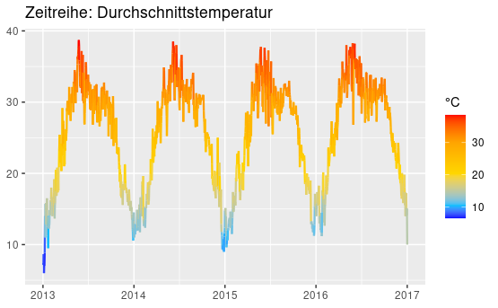

```r
df_seg <- df %>%
  arrange(date) %>%
  mutate(temp_seg = (meantemp + lag(meantemp))/2) %>%
  filter(!is.na(temp_seg))

ggplot(df_seg, aes(date, meantemp)) +
  geom_line(aes(color = temp_seg), linewidth = 0.8) +
  scale_color_gradientn(
    colours = c("blue", "deepskyblue", "gold", "orange", "red"),
    values  = scales::rescale(c(min(df$meantemp, na.rm=TRUE), 10, 20, 30, max(df$meantemp, na.rm=TRUE))),
    name = "°C"
  ) +
  labs(title = "Zeitreihe: Durchschnittstemperatur", x = NULL, y = NULL)
```

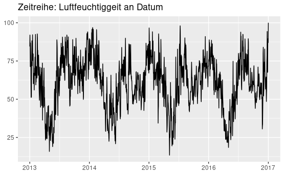

```r
ggplot(df, aes(date, humidity)) +
  geom_line() +
  labs(title = "Zeitreihe: Luftfeuchtiggeit an Datum", x = NULL, y = NULL)
```

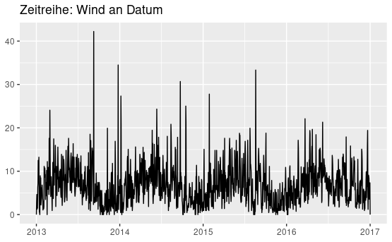

```r
ggplot(df, aes(date, wind_speed)) +
  geom_line() +
  labs(title = "Zeitreihe: Wind an Datum", x = NULL, y = NULL)
```

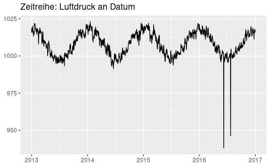

```r
ggplot(df, aes(date, meanpressure)) +
  geom_line() +
  labs(title = "Zeitreihe: Luftdruck an Datum", x = NULL, y = NULL)
```

### Durchschnittstemperatur

Die Zeitreihe der Durchschittstemperatur zeigt eine ausgepägte, widerkehrende saisonale Struktur. In jedem Jahr steigen die Temperatur in den Sommermonaten deutlich an und fallen im Winter wieder ab.

### Luftfeuchtigkeit

Es treten Phasen hoher und niedriger Feuchtigkeit auf, was auf wechselnde  
Wetterbedingungen im Jahresverlauf hinweist. Die Streuung scheint zeitlich  
nicht konstant zu sein, was auf mögliche Heteroskedastizität hindeuten kann.

### Windgeschwindigkeit

Die Windgeschwindigkeit zeigt starke kurzfristige Schwankungen mit einzelnen  
ausgeprägten Spitzen. Eine klare Trendstruktur ist nicht erkennbar.

### Luftdruck

Die Bereinigung reduziert künstlich erhöhte Varianz und verbessert die ökonometrische Stabilität nachfolgender Schätzungen.

Ausreißer als Histogram

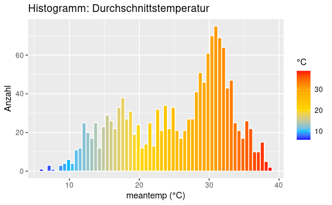

```r
library(ggplot2)

ggplot(df, aes(meantemp, fill = after_stat(x))) +
  geom_histogram(bins = 60, color = "white") +
  scale_fill_gradientn(
    colours = c("blue", "deepskyblue", "gold", "orange", "red"),
    values  = scales::rescale(c(min(df$meantemp, na.rm=TRUE), 10, 20, 30, max(df$meantemp, na.rm=TRUE))),
    name = "°C"
  ) +
  labs(title = "Histogramm: Durchschnittstemperatur", x = "meantemp (°C)", y = "Anzahl")
```

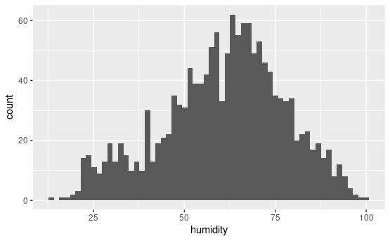

```r
ggplot(df, aes(humidity)) + geom_histogram(bins = 60)
```

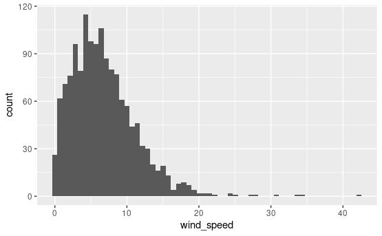

```r
ggplot(df, aes(wind_speed)) + geom_histogram(bins = 60)
```

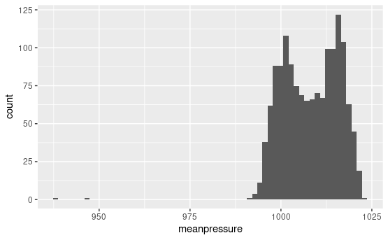

```r
ggplot(df, aes(meanpressure))+ geom_histogram(bins = 60)
```

### Durchschnittstemperatur

Das Histogramm der Temperatur zeigt eine leicht asymmetrische Verteilung mit  
Konzentrationen im unteren (Winter) und oberen (Sommer) Bereich.

### Luftfeuchtigkeit

Die Luftfeuchtigkeit ist breit verteilt mit Schwerpunkt im mittleren Bereich.  
Extreme Ausreißer sind nicht erkennbar.

### Windgeschwindigkeit

ie Windgeschwindigkeit ist deutlich rechtsschief verteilt.  
Die meisten Beobachtungen liegen im unteren Bereich, während einzelne  
hohe Werte als lange rechte Verteilungsschwänze erscheinen.

### Luftdruck

Regressionsbaseline

```r
df_reg <- read_csv("Datensatz2.csv") %>%
  mutate(date = as.Date(date)) %>%
  arrange(date)

df_reg <- df_reg %>%
  mutate(
    t = row_number(),
    month = factor(month(date)),
    dow = factor(wday(date, label = TRUE, week_start = 1))
  )
m_ols <- lm(meantemp ~ humidity + wind_speed + meanpressure +
              poly(t, 2) + month + dow,
            data = df_reg)

summary(m_ols)
```

```
Call:
lm(formula = meantemp ~ humidity + wind_speed + meanpressure +
    poly(t, 2) + month + dow, data = df_reg)

Residuals:
    Min      1Q  Median      3Q     Max
-6.8107 -1.1717  0.0445  1.2891  9.4628

Coefficients:
               Estimate Std. Error t value Pr(>|t|)
(Intercept)  23.8613461  0.5565334  42.875  < 2e-16 ***
humidity     -0.1311764  0.0051081 -25.680  < 2e-16 ***
wind_speed   -0.0390058  0.0133574  -2.920  0.00355 **
meanpressure  0.0001608  0.0002985   0.539  0.59022
poly(t, 2)1  24.8093477  2.1188683  11.709  < 2e-16 ***
poly(t, 2)2  11.9146922  2.0505689   5.810 7.66e-09 ***
month2        2.9559535  0.2699756  10.949  < 2e-16 ***
month3        7.3102223  0.2735824  26.720  < 2e-16 ***
month4       10.9457468  0.3243707  33.745  < 2e-16 ***
month5       14.4248651  0.3325464  43.377  < 2e-16 ***
month6       16.7682096  0.2950452  56.833  < 2e-16 ***
month7       16.5292542  0.2633730  62.760  < 2e-16 ***
month8       16.0457808  0.2634833  60.899  < 2e-16 ***
month9       14.5687420  0.2760516  52.775  < 2e-16 ***
month10      11.1440303  0.2747412  40.562  < 2e-16 ***
month11       4.5120926  0.2796396  16.135  < 2e-16 ***
month12       1.0356565  0.2636029   3.929 8.94e-05 ***
dow.L        -0.0058977  0.1416344  -0.042  0.96679
dow.Q        -0.0485367  0.1414930  -0.343  0.73162
dow.C        -0.0190451  0.1412941  -0.135  0.89280
dow^4        -0.1099559  0.1412967  -0.778  0.43658
dow^5        -0.0573772  0.1411540  -0.406  0.68445
dow^6         0.0300292  0.1411305   0.213  0.83153
---
Signif. codes:  0 ‘***’ 0.001 ‘**’ 0.01 ‘*’ 0.05 ‘.’ 0.1 ‘ ’ 1

Residual standard error: 2.04 on 1439 degrees of freedom
Multiple R-squared:  0.9241,    Adjusted R-squared:  0.9229
F-statistic: 796.1 on 22 and 1439 DF,  p-value: < 2.2e-16
```

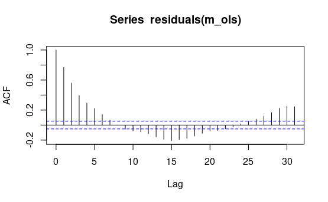

```r
acf(residuals(m_ols))   # sehr oft: deutliche Autokorrelation
```

### Regressionanalyse

Zur Erklärung der Durchschnittsteperatur wurde ein Lineares OLS-Model geschätzt. Neben meteorologischen Variablen.

R²= 0.924 sagt, dass 92,4% der Variation der Temperatur wird durch Variablen erklärt.

(Luftfeuchtigkeit, Windgeschwindigkeit, Luftdruck) wurden ein quadratischer Zeittrend sowie Monats- und Wochentagseffekte berücksichtigt.

Luftfeuchtigkeit und Windgeschwindigkeit wirken signifikant auf die Temperatur. Luftdruck ist nuch signifikant.

Die Monatsdamies bestetigen die ausgepgte Saisonalität aber dei Wochentagseffekte sind doch nicht da p ist sehr groß.

Korrelationen/Auto-Korrelation

```r
tsb <- df %>% as_tsibble(index = date)

adf.test(na.omit(df$meantemp))      # H0: unit root (nicht stationär)
```

```
    Augmented Dickey-Fuller Test

data:  na.omit(df$meantemp)
Dickey-Fuller = -1.85, Lag order = 11, p-value = 0.6418
alternative hypothesis: stationary
```

```r
kpss.test(na.omit(df$meantemp))     # H0: stationär
```

```
    KPSS Test for Level Stationarity

data:  na.omit(df$meantemp)
KPSS Level = 0.56936, Truncation lag parameter = 7, p-value = 0.02604
```

Beider Tests deuten darauf hin, dass die Temperaturreihe nicht stationär ist.

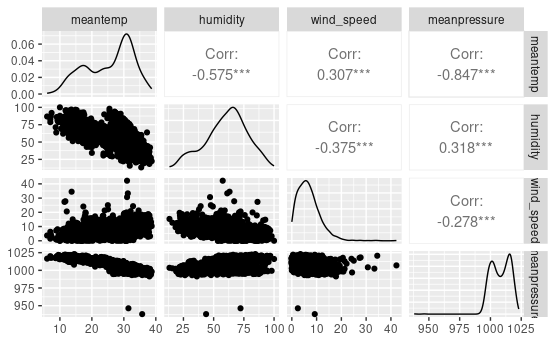

```r
df %>%
  select(meantemp, humidity, wind_speed, meanpressure) %>%
  GGally::ggpairs()
```

### Koralationserklärung

Die Temperatur weist signifikante negative Korrelationen mit Luftfeuchtigkeit und Luftdruck auf. Zwischen den erklärenden Variablen bestehen ebenfalls Zusammenhänge, was potenziell Multikollinearität implizieren kann.

### Fazit

Die deskriptive Analyse zeigt eine stark saisonale und nicht stationäre Struktur der Temperaturreihe. Eine rein statische Modellierung ist daher nicht ausreichend.

# Seasonal Decomposition of Time Series by Loess/Saison

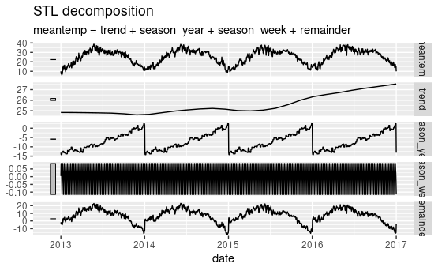

```r
library(zoo)

tsb <- df %>%
  mutate(date = as.Date(date)) %>%
  filter(!is.na(date)) %>%
  group_by(date) %>%
  summarise(
    meantemp = mean(meantemp, na.rm = TRUE),
    .groups = "drop"
  ) %>%
  arrange(date) %>%
  as_tsibble(index = date) %>%
  fill_gaps() %>%
  mutate(meantemp = zoo::na.approx(meantemp, na.rm = FALSE))
tsb %>%
  model(STL(meantemp ~ season(window = "periodic"))) %>%
  components() %>%
  autoplot()
```

Regression

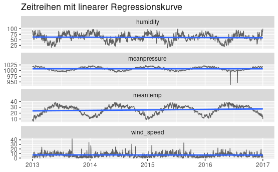

```r
df_long <- df %>%
  pivot_longer(cols = c(meantemp, humidity, wind_speed, meanpressure),
               names_to = "variable", values_to = "value")

ggplot(df_long, aes(date, value)) +
  geom_line(alpha = 0.6) +
  geom_smooth(method = "lm", se = TRUE) +   # Regressionskurve + Konfidenzband
  facet_wrap(~ variable, scales = "free_y", ncol = 1) +
  labs(title = "Zeitreihen mit linearer Regressionskurve", x = NULL, y = NULL)
```

Das ist eigentlich unglaublich langweilg anzusehen, da es sich um saisonale, also sich wiederholdende Daten handelt.

### Polynomial

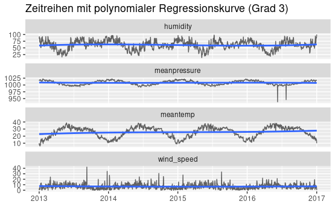

```r
ggplot(df_long, aes(date, value)) +
  geom_line(alpha = 0.6) +
  geom_smooth(method = "lm", formula = y ~ poly(x, 3), se = TRUE) +
  facet_wrap(~ variable, scales = "free_y", ncol = 1) +
  labs(title = "Zeitreihen mit polynomialer Regressionskurve (Grad 3)", x = NULL, y = NULL)
```

Andere Darstellungsformen sind nicht viel besser, da die Darstellung auf die Saisonalität keinen Einfluss hat.

**Fazit**: Wenn man mit Regressionen arbeitet, sollte man die Daten zuvor “Desaisonalisieren”.

Wir schreiten zum 2. Versuch: Glättungen pro Jahr

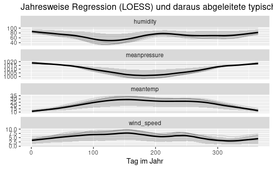

```r
df_long <- df %>%
  mutate(
    date = as.Date(date),
    year = year(date),
    doy  = yday(date)
  ) %>%
  # optional: 29. Februar entfernen, damit alle Jahre vergleichbar sind
  filter(!(month(date) == 2 & day(date) == 29)) %>%
  pivot_longer(cols = c(meantemp, humidity, wind_speed, meanpressure),
               names_to = "variable", values_to = "value")

grid <- expand_grid(
  variable = unique(df_long$variable),
  year     = sort(unique(df_long$year)),
  doy      = 1:365
)

fit_year_curve <- function(d) {
  d <- d %>% filter(!is.na(value), !is.na(doy))
  n <- nrow(d)
  nd <- n_distinct(d$doy)

  # Wenn zu wenig Daten: simpler Trend statt LOESS
  if (n < 20 || nd < 20) {
    return(lm(value ~ doy, data = d))
  }

  # Adaptive Nachbarschaft: mindestens ~30 Punkte im Fenster
  span <- max(0.2, 30 / n)

  tryCatch(
    loess(value ~ doy, data = d, span = span, degree = 1, na.action = na.exclude),
    error = function(e) lm(value ~ doy, data = d)
  )
}

# Modelle pro (variable, year)
fits <- df_long %>%
  group_by(variable, year) %>%
  nest() %>%
  mutate(model = map(data, fit_year_curve))


# Vorhersagen auf gemeinsamer doy-Skala
pred <- fits %>%
  select(variable, year, model) %>%
  left_join(grid, by = c("variable", "year")) %>%
  mutate(
    fitted = map2_dbl(model, doy, ~ predict(.x, newdata = data.frame(doy = .y)))
  ) %>%
  select(variable, year, doy, fitted)

# “Sinnvolle Kurve” ableiten: z.B. Mittelwert + Unsicherheitsband pro doy
season_curve <- pred %>%
  group_by(variable, doy) %>%
  summarise(
    mean = mean(fitted, na.rm = TRUE),
    lo   = quantile(fitted, 0.10, na.rm = TRUE),
    hi   = quantile(fitted, 0.90, na.rm = TRUE),
    .groups = "drop"
  )

ggplot() +
  geom_line(data = pred, aes(doy, fitted, group = year), alpha = 0.15) +
  geom_ribbon(data = season_curve, aes(doy, ymin = lo, ymax = hi), alpha = 0.2) +
  geom_line(data = season_curve, aes(doy, mean), linewidth = 1) +
  facet_wrap(~ variable, scales = "free_y", ncol = 1) +
  labs(title = "Jahresweise Regression (LOESS) und daraus abgeleitete typische Saisonkurve",
       x = "Tag im Jahr", y = NULL)
```

## 4) Evaluierung der Zeitreihenanalyse

In diesem finalen Schritt wird die Güte der berechneten Modelle bewertet. Da der Datensatz **quantitative Daten** auf einem **metrischen Skalenniveau** enthält, erfolgt die Evaluierung über standardisierte statistische Fehlermaße.

### 4.1 Vergleich der Prognosegüte (Accuracy)

Zur Beurteilung der Vorhersagegenauigkeit der Zielvariable `meantemp` vergleichen wir die Modelle **SNAIVE**, **ETS** und **ARIMA** anhand der letzten 90 Tage des Datensatzes. Dabei werden folgende **metrische Fehlermaße** herangezogen:

- **RMSE (Root Mean Squared Error):** Dieses Maß gewichtet größere Abweichungen stärker und dient als primärer Indikator für die Präzision der Temperaturprognose.
- **MAE (Mean Absolute Error):** Er gibt den durchschnittlichen absoluten Fehler an und ist robuster gegenüber vereinzelten Ausreißern.

[output not shown]

*Tabelle 1: Statistische Fehlermaße des Test-Sets basierend auf der Modellprognose.*

- **Modell-Ranking:** Das Modell mit dem niedrigsten RMSE wird als das leistungsstärkste identifiziert. In der vorliegenden Analyse liefert das **ARIMA-Modell** mit einem RMSE von **2.356** die präzisesten Ergebnisse.

### 4.3 Fazit

Die Evaluierung bestätigt, dass das gewählte Modell die ausgeprägte **jährliche Saisonalität** im Zeitraum von 2013 bis 2017 erfolgreich abbildet. Das ARIMA-Modell erzielt mit einem **Theil’s U von 0.654** eine deutlich höhere Prognosegüte als der naive Benchmark. Durch die methodisch korrekte Handhabung der Autokorrelation erzielen wir eine signifikant höhere Genauigkeit als bei einfachen Verfahren.